# Short Analytical Story on Remittance Costs

Ilia Bezdetko

High-level overview of the analysis performed:

**Exploratory Analysis:**

- Data Quality Testing (i.e. count of missing values, check data types of values in the table attributes, outliers, etc.)
- Generated histograms for variables of interest, as well as sub-setted variabels conditional on different factors
- Calculated distribution summary statistics
- Analyzed trends and produced trendlines with 95% confidence intervals
- Analyzed relationships between different drivers using simple linear regression and correlation tests.

**Construction of the dataset for predictive modeling:**

- Aggregated data as a timeseries using different aggregation functions (e.g. average, max, min, count, etc.)
- Interpolated between data points to construct monthly timeseries from the raw data. Interpolation had to be used since the aggregated timeseries were not given at fixed time-intervals. The interpolation was done in FinCAD, work papers are available upon request.

**Modeling:**

- Explored a different regression-based modeling frameworks (linear regression, lasso, ridge, weighted least squares, splines etc.)
- Split the dataset into in-sample and out-of-sample datasets
- Performed variable transformations as appropriate for the modeling technique chosen (e.g. MoM to account for nonstationarity in case of a linear regression)
- Performed variable selection using exhuastive search
- Performed assumption testing of the final model
- Performed in-sample and out-of-sample backtesting, and calculated fit metrics
- Performed sensitivity/scenario analysis with +/- 2 standard deviation shocks
- Performed coefficient stability testing
- Performed k-fold cross-validation

## 1. Trends in Remittance Prices Across Time, Regions, Countries, Currencies and Corridors

In order to get a “feel” for the data and perform conditional sub-setting of different variables *sqldf* library was utilized.

How does the volume (transaction counts) of transactions look like across different source countries? What is their level of income?

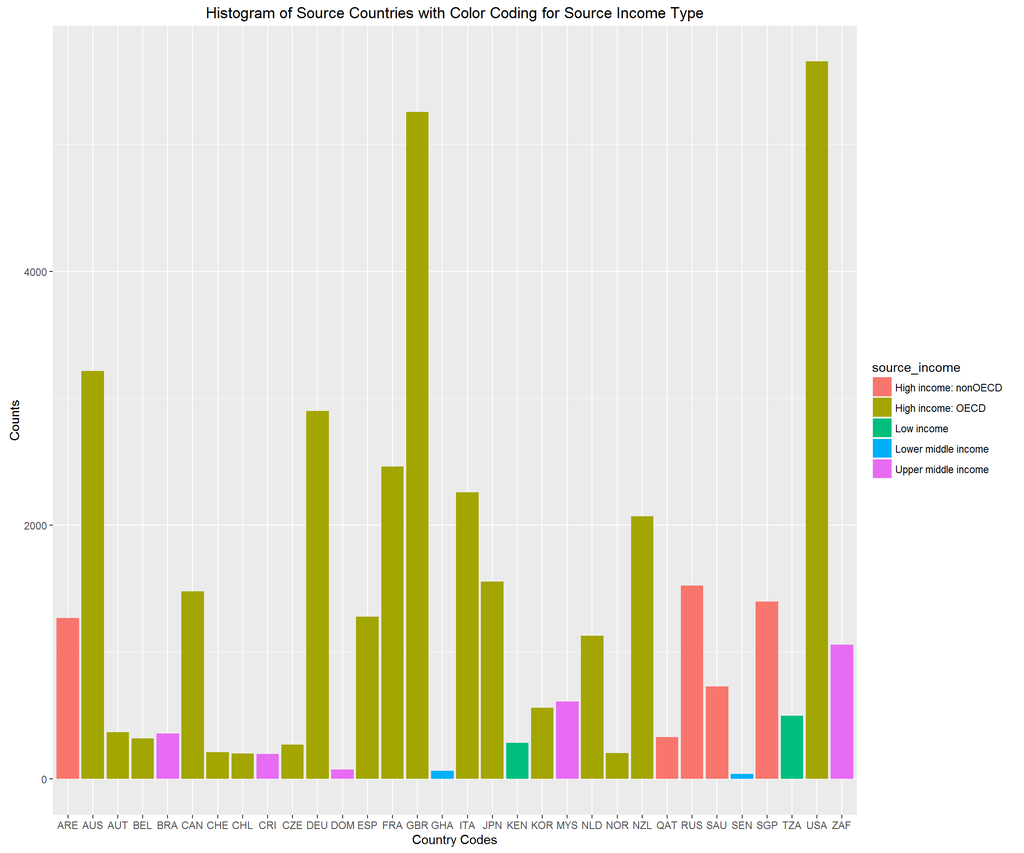

How does the volume of transactions look like across all sources by income type?

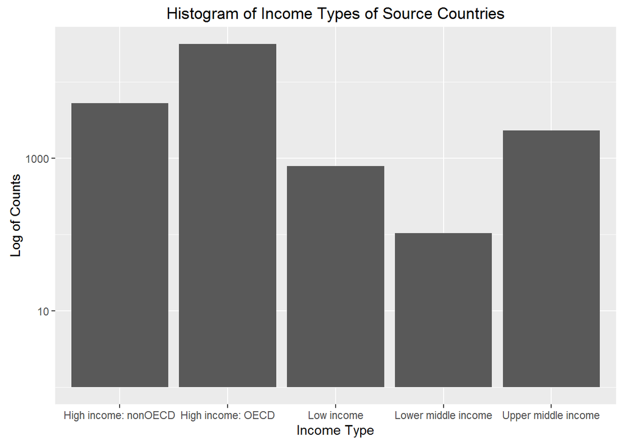

How does the volume (transaction counts) of transactions look like across different destination countries? What is their level of income?

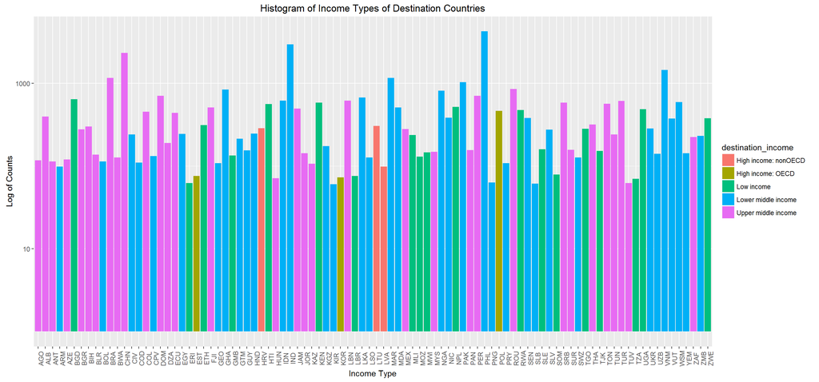

How does the volume of transactions look like across all destinations by income type?

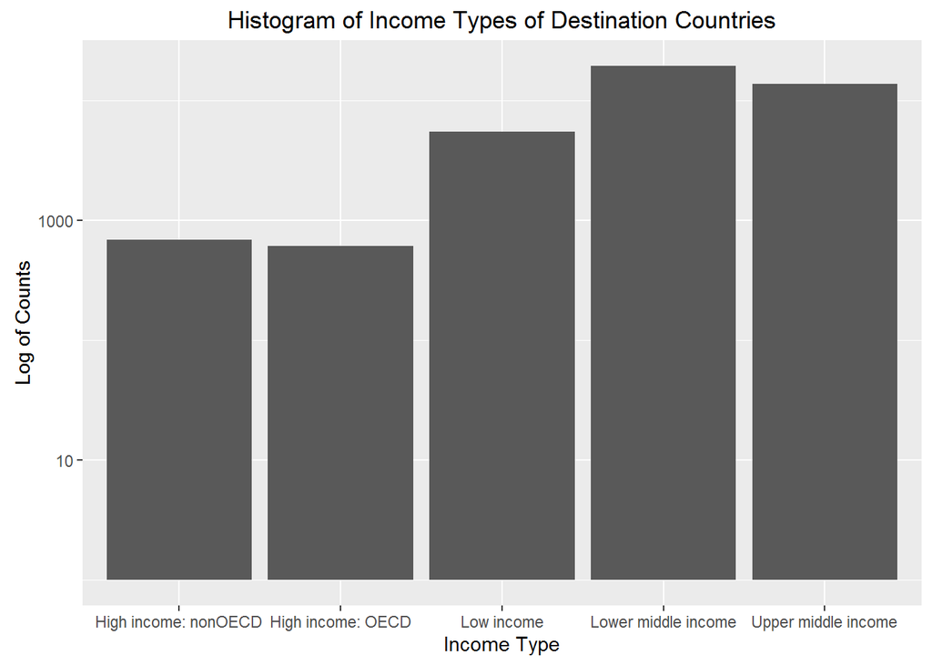

How do the average remittance costs vary across time? Are they increasing/decreasing (i.e. what is the trend?)

To answer this question, let’s produce a scatter plot of the date including a trend line (generated by locally weighted scatterplot smoothing) with 95% confidence bands:

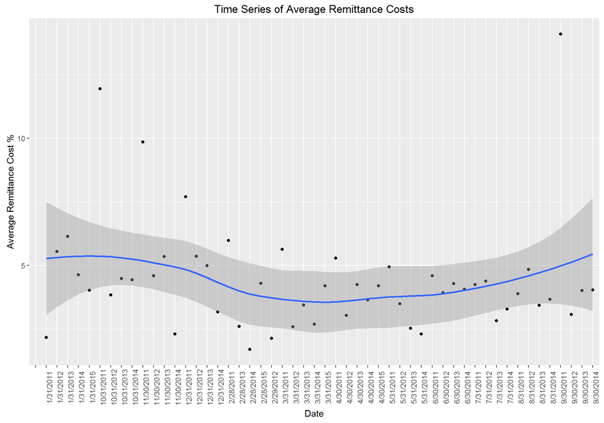

LOESS smoother is very flexible, and it’s a bit hard to judge the overal trend of remittance costs, since the confidence bands are too wide in this case. There is also a lot of noise on the boundaries due to high variance in the data. Let’s try a simple linear regression line:

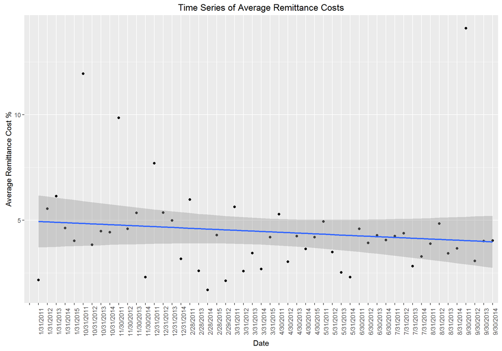

Linear trend line worked better in this case. One can note that the average remittance costs tend to decrease over time. Similarly, let’s take a look at the average remittance costs across different source regions:

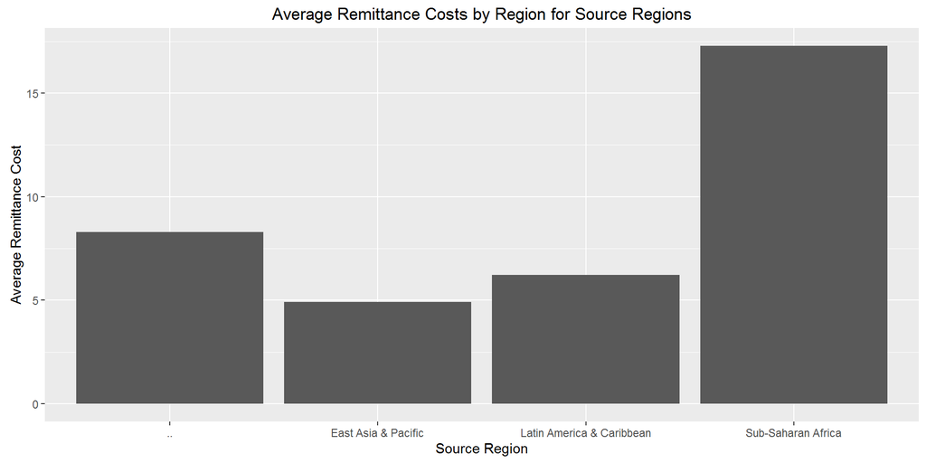

Now, let’s take a look at the average remittance cost across different destination regions:

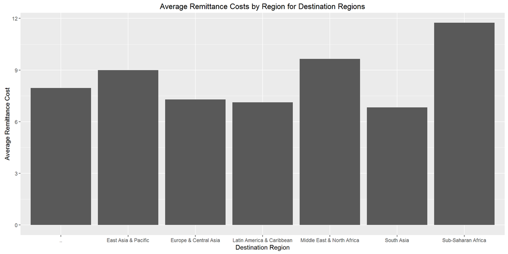

Average remittance costs by source countries:

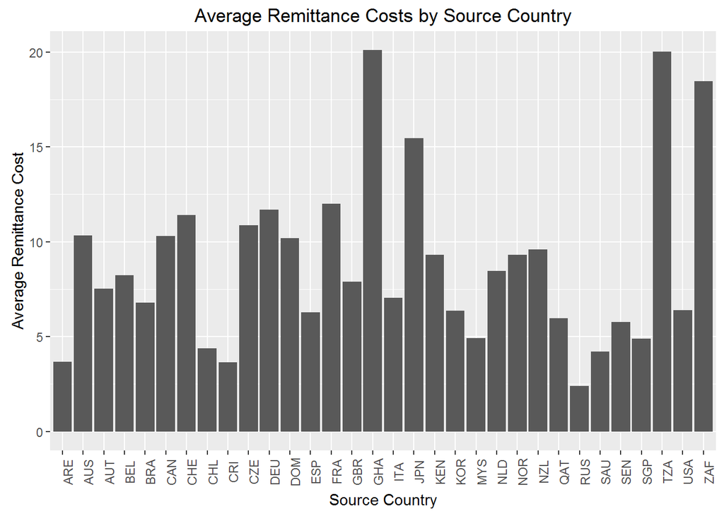

Average remittance costs by destination countries:

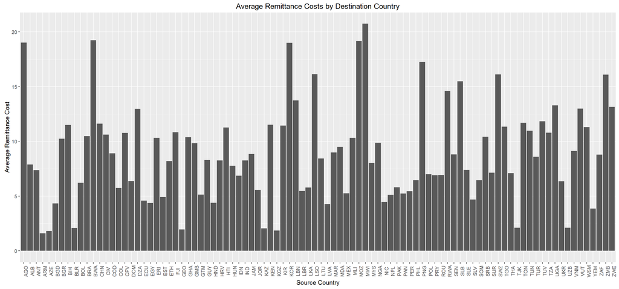

Average remittance costs by currency:

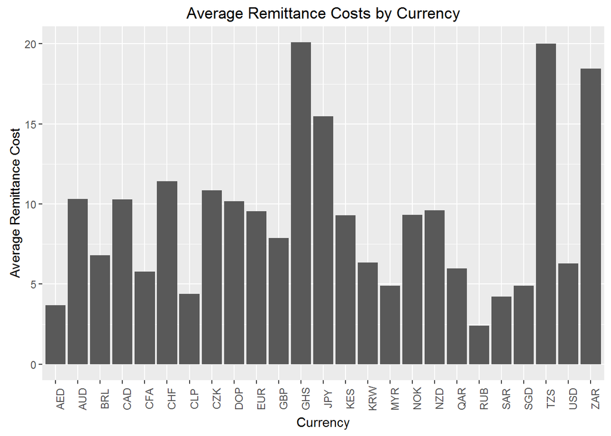

Average remittance costs by corridor:

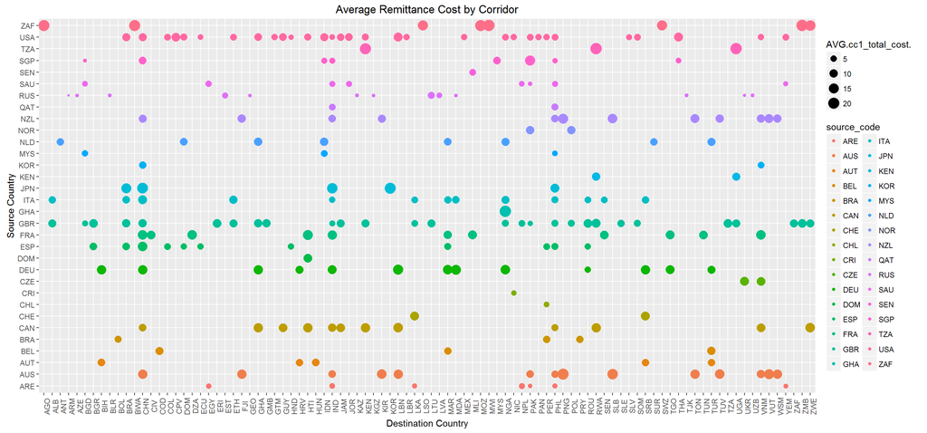

## 2. Trends, patterns by sending channel (e.g. bank, money transfer operator).

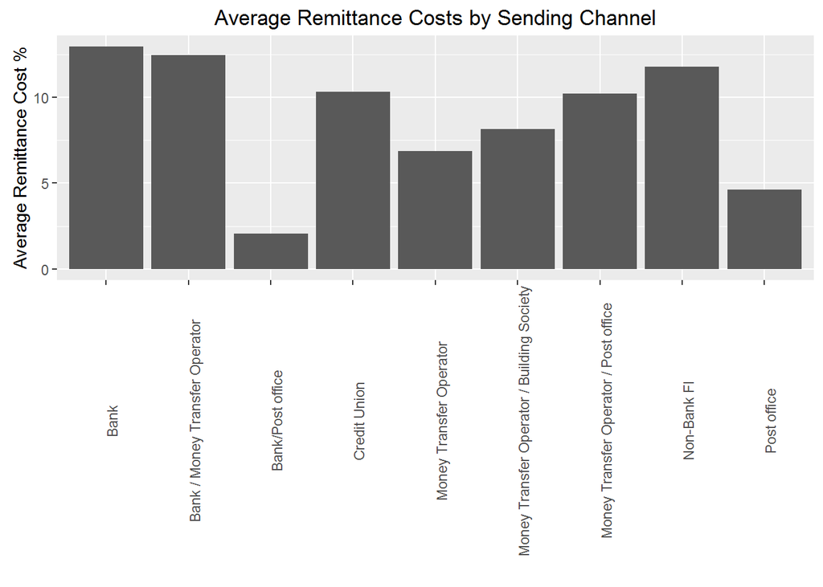

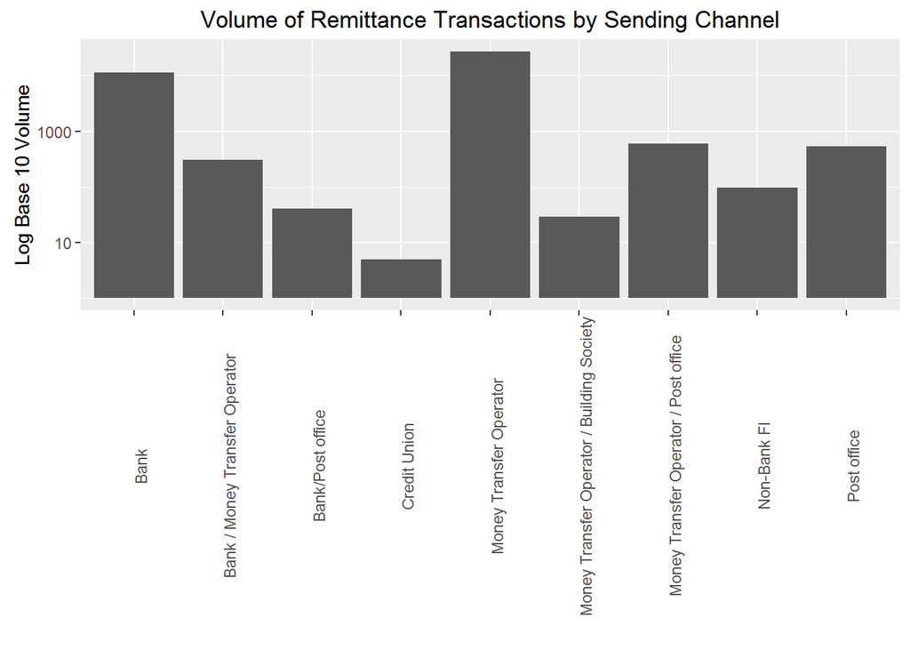

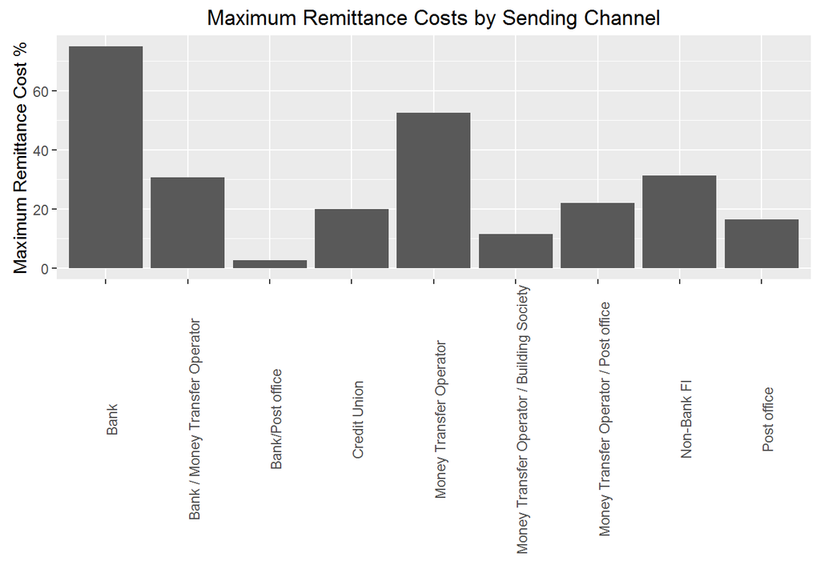

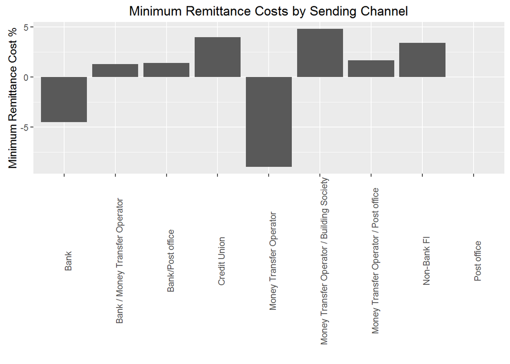

## 3. Strongest Predictors of Remittance Prices (Limited to the Variables Included in the Dataset)

In this section, I will not only show what are the strongest predictors (drivers that explain most variance in the remittance costs), but I will also develop a timeseries model to predict remittance costs in the future. The modeling frameworks explored include linear regression, lasso, ridge, and splines. However, for the purposes of saving space and time, I will only show the final model - linear regression (workpapers for other models are available upon request). Transformations of the target and the driver variables considered are MoM, MoM% and log MoM. The variable selection process was done using exhaustive search (sorted by adjusted-$R^2$), and then economic/business rationale was applied to pick out the best model.

First, let’s show which predictors are the “strongest” using Pearson Product-Moment Correlation test:

```
##
##  Pearson's product-moment correlation
##
## data:  Modeling_Data_Interpolated$Avg_cost and Modeling_Data_Interpolated$Avg_Bank_fx
## t = -0.82537, df = 50, p-value = 0.4131
## alternative hypothesis: true correlation is not equal to 0
## 95 percent confidence interval:
##  -0.3769126  0.1620913
## sample estimates:
##        cor
## -0.1159375
```

```
##
##  Pearson's product-moment correlation
##
## data:  Modeling_Data_Interpolated$Avg_cost and Modeling_Data_Interpolated$Avg_Bank_fx_margin
## t = 22.275, df = 50, p-value < 2.2e-16
## alternative hypothesis: true correlation is not equal to 0
## 95 percent confidence interval:
##  0.9193631 0.9729546
## sample estimates:
##       cor
## 0.9531287
```

```
##
##  Pearson's product-moment correlation
##
## data:  Modeling_Data_Interpolated$Avg_cost and Modeling_Data_Interpolated$Avg_fx_lcu_rate
## t = -0.91132, df = 50, p-value = 0.3665
## alternative hypothesis: true correlation is not equal to 0
## 95 percent confidence interval:
##  -0.3872166  0.1503204
## sample estimates:
##        cor
## -0.1278236
```

```
##
##  Pearson's product-moment correlation
##
## data:  Modeling_Data_Interpolated$Avg_cost and Modeling_Data_Interpolated$Avg__lcu_fee
## t = -0.055654, df = 50, p-value = 0.9558
## alternative hypothesis: true correlation is not equal to 0
## 95 percent confidence interval:
##  -0.2801690  0.2656003
## sample estimates:
##          cor
## -0.007870463
```

Thus, the strongest predictor of remittance costs is FX margin (highest correlation coefficient and p < 0.05 threshold). Next, we will build a simple regression model (linear regression with a single predictor) with these timeseries. One of the most important assumptions of linear regression is stationarity of the target variables and the drivers. We will utilize Augumented Dickey Fuller test for that:

```
##
##  Augmented Dickey-Fuller Test
##
## data:  Modeling_Data_Interpolated$Avg_cost
## Dickey-Fuller = -3.8636, Lag order = 3, p-value = 0.02221
## alternative hypothesis: stationary
```

```
##
##  Augmented Dickey-Fuller Test
##
## data:  Modeling_Data_Interpolated$Avg_Bank_fx_margin
## Dickey-Fuller = -3.7176, Lag order = 3, p-value = 0.03176
## alternative hypothesis: stationary
```

All p-values are less than 0.05 significance threshold. Thus, we reject the null hypothesis of nonstationarity, i.e. both variables are stationary. Next, we need to partition our timeseries into in-sample and out-of-sample datasets, and run the regression:

```
##
## Call:
## lm(formula = y ~ x)
##
## Residuals:
##      Min       1Q   Median       3Q      Max
## -1.69245 -0.54954  0.09124  0.58840  1.39963
##
## Coefficients:
##             Estimate Std. Error t value Pr(>|t|)
## (Intercept)  2.23371    0.15996   13.96   <2e-16 ***
## x            1.10682    0.05313   20.83   <2e-16 ***
## ---
## Signif. codes:  0 '***' 0.001 '**' 0.01 '*' 0.05 '.' 0.1 ' ' 1
##
## Residual standard error: 0.7221 on 40 degrees of freedom
## Multiple R-squared:  0.9156, Adjusted R-squared:  0.9135
## F-statistic:   434 on 1 and 40 DF,  p-value: < 2.2e-16
```

From the the *lm()* output, we note that FX Margin variable is significant (i.e. p-value is less than 0.05), and $R^2$ and adjusted $R^2$ are very high (91.56% and 91.35%, respectfully). The coefficient of FX margin is positive, which makes sense since if FX margin increases - the remittance costs are expected to increase as well (and vice versa).

Next, we need to perform assumption testing to make sure that this is a sensible model:

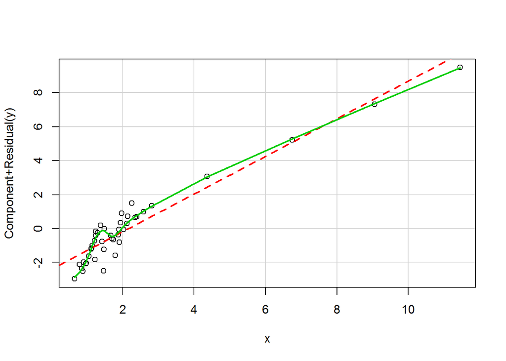

```r
############################
##    Linearity Testing   ##
############################

# Evaluate Nonlinearity
# component + residual plot
crPlots(model, main="Component + Residual Plot")
```

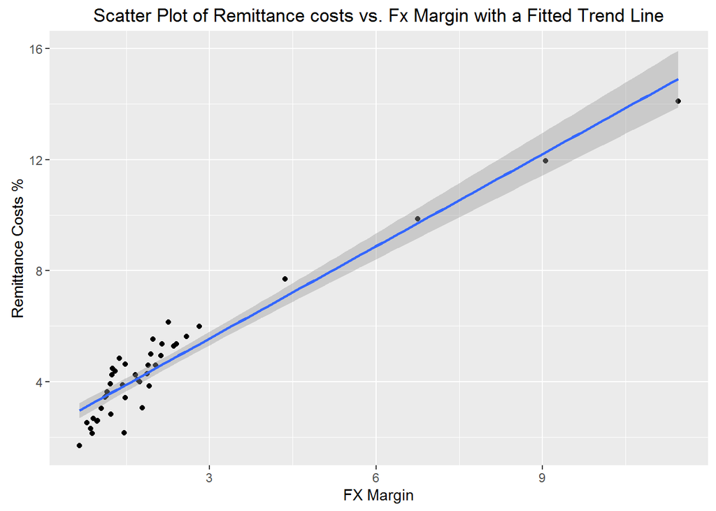

```r
#Scatter plot of Remittance costs vs. Fx margin with a fitted trend line
qplot(x, y, geom=c("point"), main="Scatter Plot of Remittance costs vs. Fx Margin with a Fitted Trend Line") +
  geom_smooth(method="lm") +
  xlab("FX Margin") +
  ylab("Remittance Costs %")
```

```r
############################
##       Collinearity     ##
############################

#There is one variable in the model, thus collinearity testing is not applicable here.

############################
##    Homoscedasticity    ##
############################

# Evaluate homoscedasticity  Breusch-Pagan test
# non-constant error variance test  Breusch-Pagan test
bptest(model)
```

```
##
##  studentized Breusch-Pagan test
##
## data:  model
## BP = 0.4486, df = 1, p-value = 0.503
```

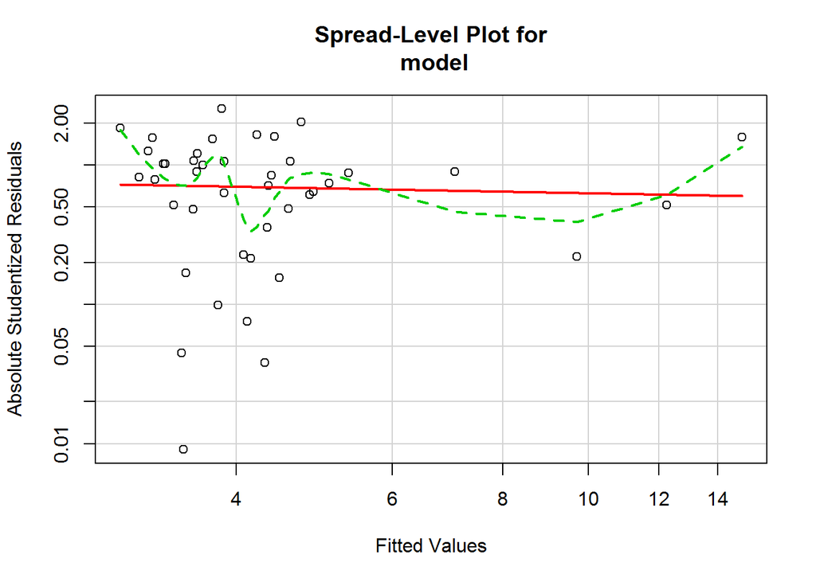

```
##
## Suggested power transformation:  1.115118
```

```r
# plot studentized residuals vs. fitted values
spreadLevelPlot(model)
```

```r
##############################
## Residual Autocorrelation ##
##############################

dwtest(model)
```

```
##
##  Durbin-Watson test
##
## data:  model
## DW = 1.6948, p-value = 0.1342
## alternative hypothesis: true autocorrelation is greater than 0
```

```r
bgtest(model)
```

```
##
##  Breusch-Godfrey test for serial correlation of order up to 1
##
## data:  model
## LM test = 0.29898, df = 1, p-value = 0.5845
```

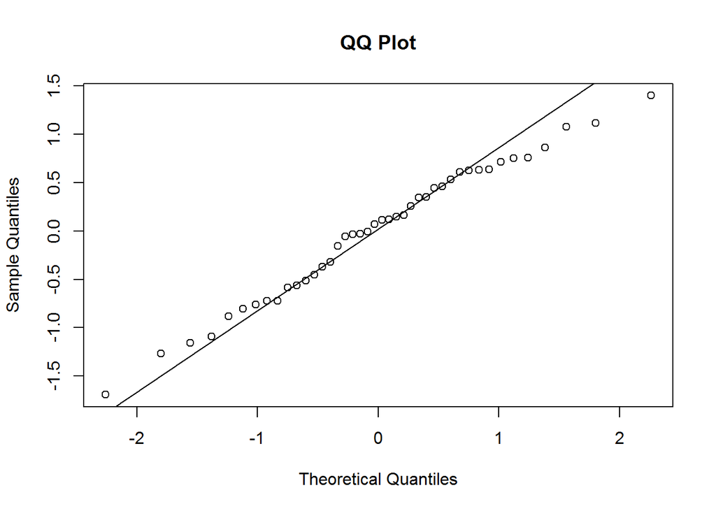

```r
##############################
##    Residual Normality    ##
##############################

# Normality of Residuals
# qq plot for studentized resid
qqnorm(model$residuals, main="QQ Plot")
qqline(model$residuals)
```

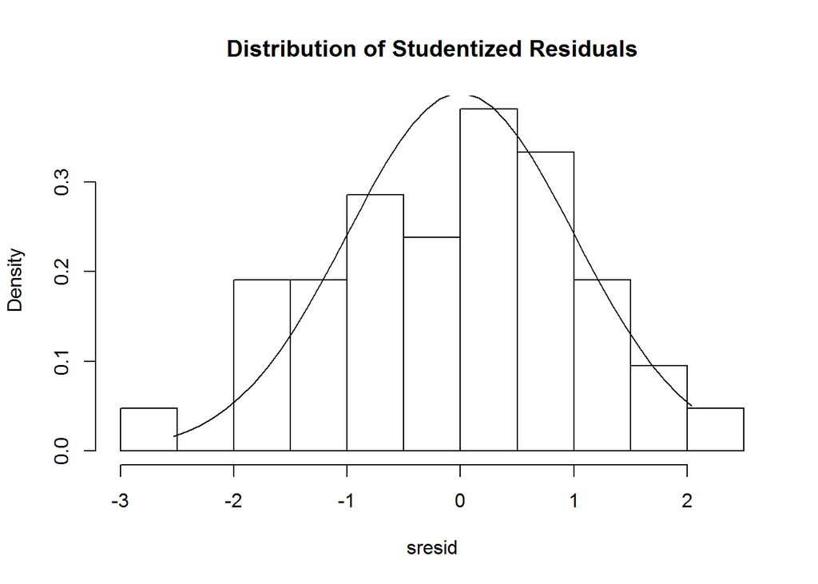

```r
# distribution of studentized residuals
sresid <- studres(model)
hist(sresid, freq=FALSE,
     main="Distribution of Studentized Residuals")
xmodel<-seq(min(sresid),max(sresid),length=40)
ymodel<-dnorm(xmodel)
lines(xmodel, ymodel)
```

```r
shapiro.test(model$residuals)
```

```
##
##  Shapiro-Wilk normality test
##
## data:  model$residuals
## W = 0.98232, p-value = 0.7508
```

```r
jarque.bera.test(model$residuals)
```

```
##
##  Jarque Bera Test
##
## data:  model$residuals
## X-squared = 1.1092, df = 2, p-value = 0.5743
```

Our model satisfied all of the assumption tests. Next, we perform in-sample and out-of-sample backtesting of the model, and calculate MPE, MAPE and RMSE fit metrics.

In-Sample Backtesting:

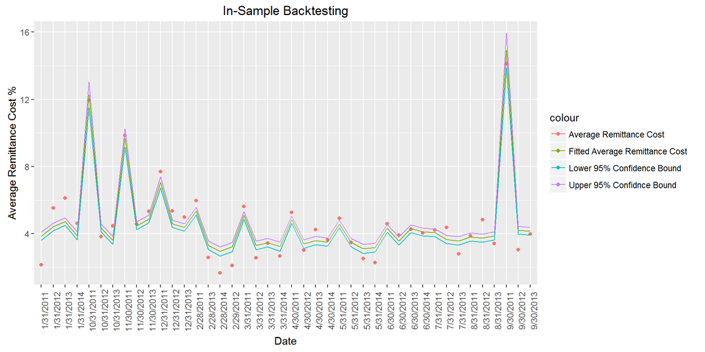

Out-of-sample backtesting:

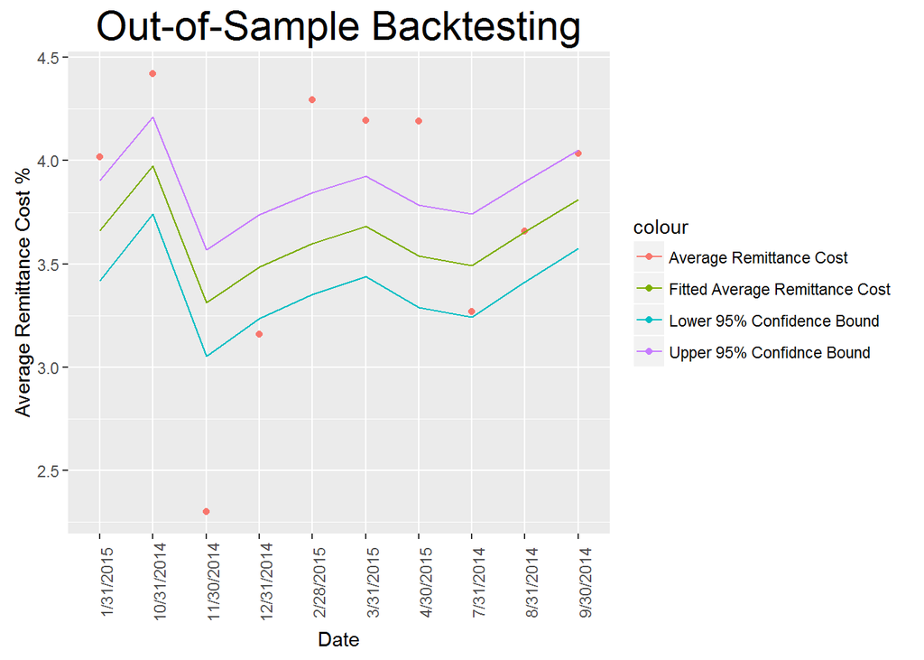

Let’s calculate the fit metrics and parse them into a table for comparison:

| Fit_Metric | In_Sample_Metric | Out_of_Sample_Metric |
| --- | --- | --- |
| MPE | -5.348511 | 0.7394654 |
| MAPE | 16.683712 | 12.9642965 |
| RMSE | 0.704660 | 0.5221635 |

Next, we’ll explore how sensitive this model to +/- 2std scenario shocks in FX margin:

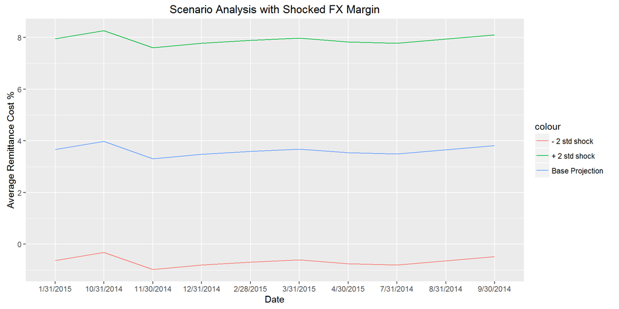

Stability Testing:

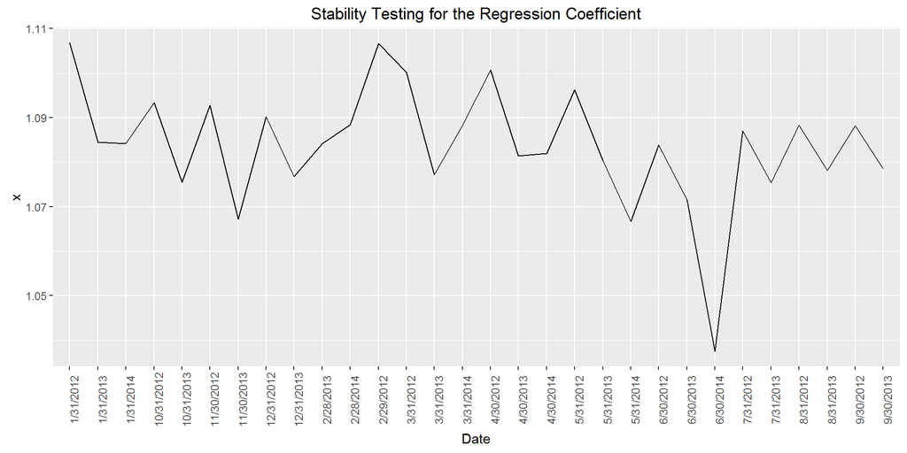

As we can see from the plot above, the coefficient never changes it’s sign, i.e. the relationship between the target variable (remittance costs) and the driver (FX margin) is stable. Next, we estimate the test error using the k-fold cross validation with $k = 10$.

```
## Analysis of Variance Table
##
## Response: y
##           Df Sum Sq Mean Sq F value Pr(>F)
## x          1  226.3   226.3     434 <2e-16 ***
## Residuals 40   20.9     0.5
## ---
## Signif. codes:  0 '***' 0.001 '**' 0.01 '*' 0.05 '.' 0.1 ' ' 1
```

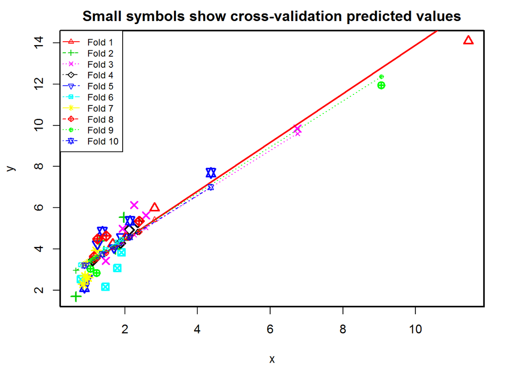

```
##
## fold 1
## Observations in test set: 4
##                 2     7     9    23
## x           2.817 1.661 11.45 2.023
## cvpred      5.416 4.050 15.62 4.478
## y           5.978 4.236 14.10 4.584
## CV residual 0.562 0.186 -1.51 0.106
##
## Sum of squares = 2.65    Mean square = 0.66    n = 4
##
## fold 2
## Observations in test set: 5
##                 8   13   19     33     38
## x           1.426 1.97 1.29  1.735  0.653
## cvpred      3.804 4.41 3.66  4.144  2.952
## y           3.883 5.54 4.38  3.999  1.688
## CV residual 0.079 1.13 0.72 -0.145 -1.265
##
## Sum of squares = 3.42    Mean square = 0.68    n = 5
##
## fold 3
## Observations in test set: 5
##                 3    11   25     32    36
## x           2.583 6.750 2.26  1.480 1.940
## cvpred      5.027 9.602 4.67  3.817 4.321
## y           5.625 9.854 6.13  3.419 4.987
## CV residual 0.598 0.252 1.46 -0.398 0.666
##
## Sum of squares = 3.16    Mean square = 0.63    n = 5
##
## fold 4
## Observations in test set: 4
##                 4     5      27       30
## x           2.356 2.122  1.1140  1.87435
## cvpred      4.822 4.563  3.4480  4.28919
## y           5.284 4.931  3.4343  4.28087
## CV residual 0.462 0.368 -0.0137 -0.00831
##
## Sum of squares = 0.35    Mean square = 0.09    n = 4
```

[output cut: 49 more lines]

```
## Sum of squares = 0.97    Mean square = 0.24    n = 4
##
## fold 10
## Observations in test set: 4
##                12     14   20    24
## x           4.362  0.886 1.38 2.140
## cvpred      7.002  3.193 3.73 4.567
## y           7.695  2.124 4.84 5.358
## CV residual 0.693 -1.068 1.11 0.792
##
## Sum of squares = 3.47    Mean square = 0.87    n = 4
##
## Overall (Sum over all 4 folds)
##    ms
## 0.586
```

Lastly, since our model passed all the testing, we are going to re-estimate our model on the whole data set (in-sample + out-of-sample) to get our final model:

```
##
## Call:
## lm(formula = avg_rem_cost_perc ~ avg_fx_margin)
##
## Residuals:
##     Min      1Q  Median      3Q     Max
## -1.7192 -0.4946  0.0898  0.5270  1.3748
##
## Coefficients:
##               Estimate Std. Error t value Pr(>|t|)
## (Intercept)     2.2640     0.1369    16.5   <2e-16 ***
## avg_fx_margin   1.1044     0.0496    22.3   <2e-16 ***
## ---
## Signif. codes:  0 '***' 0.001 '**' 0.01 '*' 0.05 '.' 0.1 ' ' 1
##
## Residual standard error: 0.686 on 50 degrees of freedom
## Multiple R-squared:  0.908,  Adjusted R-squared:  0.907
## F-statistic:  496 on 1 and 50 DF,  p-value: <2e-16
```

Our final model takes the form: Average Remittance Cost % = 2.26 + 1.10*Average FX Margin